# Evaluation report and metrics

X-CUBE-AI 4.0.0 Expansion Package

r1.0

AI PLATFORM r4.0.0 (Embedded Inference Client API 1.3.0)

Command Line Interface r1.0.0

# 1 Introduction

This application note describes the different metrics which are reported to evaluate the generated C-model during the *validation* process. According the type of the original model (floating-point or quantized model) and the provided samples (inputs or/and reference outputs), the following metrics will be computed.

| Metric | Description |
| --- | --- |
| ACC | Accuracy (Classification accuracy) |
| RMSE | Root Mean Square Error |
| MAE | Mean Absolute Error |
| L2r | L2 relative Error |
| CM | Confusion matrix |

**Note** — In this document, C-model refers to the execution of the *X86* or *STM32* C-model. In both case, same evaluation or validation flow is applied (see [[2]](https://www.st.com/en/embedded-software/x-cube-ai.html#resource)).

**Note** — **Readers** should be aware that in all case, the used input data and generated output data are stored in the specific files, see *“Post-processing support”* section.

## 1.1 Input validation files

The user can provide the inputs and associated ground truth values in a simple file (`npz` numpy format) or two separated files (`npy` numpy format or `csv` format).

- `csv` files are text files with a flattened version of the input (or output) tensors, one by line. Comma `,` separator is used to separate the values.
- `npy` files are the standard numpy binary format to store a single array.
- `npz` file is a standard numpy binary format to store several arrays. Only the following dict entries are currently supported to store the data: `'x_test'` and `'y_test'` or `'in_0'` and `'out_0'` or `'m_inputs'` and `'m_outputs'`

**Note** — In all case, only float32-type values are expected. For the quantized models, pre-process is applied to convert the data according the expected format. Same conversion is done for the outputs.

**Note** — Ground truth values should be provided as one-shot-encoding format aligned with the network output shape.

## 1.2 Post-processing support

In all cases, with or without custom data, the input and generated predicted values are stored in different files. This allows to use a post-processing script to evaluate user-defined metrics.

**Note** — Be aware that the stored values are **always** the `float32` data-type in **HWC** order (format which is used by the STM32 `network_runtime` library).

```
...
Creating <output-directory-path>\<name>_valid_m_inputs.csv
Creating <output-directory-path>\<name>_valid_c_inputs.csv
Creating <output-directory-path>\<name>_valid_m_outputs.csv
Creating <output-directory-path>\<name>_valid_c_outputs.csv
Creating <output-directory-path>\<name>_valid_io.npz
...
```

- The generated `csv` files are text files with a flattened version of the input (or output) tensors, one by line. Comma `,` separator is used to separate the values.
- The `npz` file is a standard numpy binary format to store several arrays. The following dict entries are respectively used to store the data: `'m_inputs'`, `'c_inputs'`, `'m_outputs'` and `'c_outputs'`.

> For the `*.csv` files, only the first 64 samples are stored.

## 1.3 References

| [[1]](https://www.st.com/en/embedded-software/x-cube-ai.html) | X-CUBE-AI - *AI expansion pack for STM32CubeMX* https://www.st.com/en/embedded-software/x-cube-ai.html |
| --- | --- |
| [[2]](https://www.st.com/en/embedded-software/x-cube-ai.html#resource) | UM2526 - *Getting started with X-CUBE-AI Expansion Package for Artificial Intelligence (AI)* https://www.st.com/en/embedded-software/x-cube-ai.html#resource |
| [3] | stm32ai - Command Line Interface |
| [4] | Embedded inference client API |

# 2 Reported metrics

## 2.1 Classification accuracy (acc)

*Classification accuracy* is what we usually mean, when the term *accuracy* is used. *ACC* is the ratio between of correct predictions to the total number of inputs.

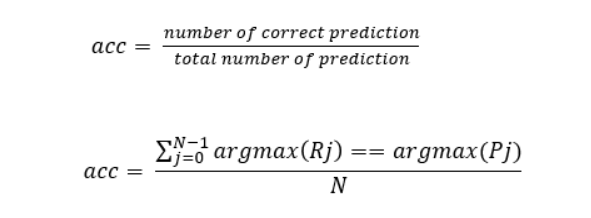

Figure 1: ACC computation

```python
import numpy as np
from sklearn.metrics import accuracy_score

def acc(ref, pred):
  """Classification accuracy (ACC)."""
  return accuracy_score(np.argmax(ref, axis=1), np.argmax(pred, axis=1))
```

## 2.2 Mean Absolute Error (mae)

*MAE* is the average of the difference between the original value (or reference value, Rj) and the predicted value (Pj). It gives the measure of how far the predictions were from the actual output. However, they don’t gives any idea of the direction of the error i.e. whether we are under predicting the data or over predicting the data. *MAE* is computed for the flattened array (element-wise along the array), returning a scalar value.

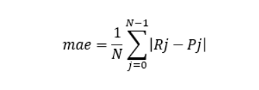

Figure 2: MAE computation

```python
import numpy as np

def mae(ref, pred):
  """Return Mean Absolute Error (MAE)."""
  return (np.abs(ref - pred).astype(np.float64)).mean()
```

## 2.3 Root Mean Square Error (rmse)

*RMSE* is quite similar to *MAE*, the only difference being that *RMSE* takes the average of the square of the difference between the original values and the predicted values. As, we take square of the error, the effect of larger errors become more pronounced then smaller error, hence the model can now focus more on the larger errors. *RMSE* is computed for the flattened array (element-wise along the array), returning a scalar value.

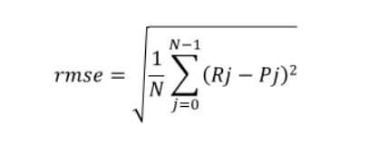

Figure 3: RMSE computation

```python
import numpy as np

def rmse(ref, pred):
  """Return Root Mean Squared Error (RMSE)."""
  return np.sqrt(((ref - pred).astype(np.float64) ** 2).mean())
```

## 2.4 L2 relative error (l2r)

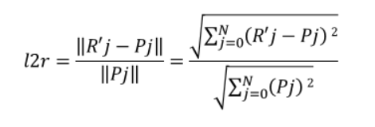

Figure 4: L2r computation

```python
import numpy as np

def l2r(ref, pred):
  """Compute L2 relative error"""
  def magnitude(v):
    return np.sqrt(np.sum(np.square(v).flatten()))
  mag = magnitude(pred) + np.finfo(np.float32).eps
  return magnitude(ref - pred) / mag
```

## 2.5 Confusion matrix (CM)

When custom outputs are provided, a confusion matrix is reported for the C-model and the reference model. It describes the complete performance of the model (classifier type).

```bash
8 classes (50 samples)
------------------------------------------------
C0         4    .    .    .    .    .    .    .
C1         .    9    .    .    .    .    .    .
C2         .    .    6    .    .    .    .    .
C3         .    .    .    7    .    .    .    .
C4         .    .    .    .    5    .    .    .
C5         .    .    .    .    .    6    .    .
C6         .    .    .    .    .    .    7    .
C7         .    .    .    .    .    .    .    6
```

*Cross* confusion matrix or accuracy uses the outputs of the reference model to build the ground truth values. They are used to evaluate and to compare the performance of the C-model.

**Note** – It is only displayed when the number of class is inferior or equal to 20.

# 3 Use cases

## 3.1 Floating-point model - Input values only

Default case where only the input values are used to evaluate the generate C-model from a floating-point model. The same inputs (*I*) (random data or custom data) are used to feed the original model and the generated C-model. The outputs (*P* and *R’*) are mainly used to build the *L2r* error in this case. However, *R’* is also used as reference to compute the cross metrics: *ACC*, *RMSE* and *MAE*. These metrics (and associated confusion matrix) allow to enhance the *L2r* metric with additional indicators, in particular when random data are used and compression factor is applied.

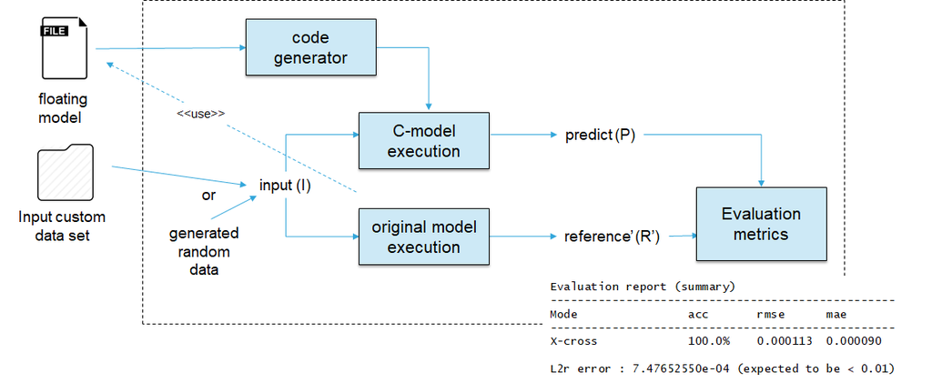

Figure 5: Floating-point model with input values only

**Note** — By construction, evaluation of a generated C-model from a floating-point model is more accurate with the custom input values, sub-set of the test or validation data set. Because the generated random samples are uniformly distributed (fixed seed) inside *[-1.0, 1.0]*, and not necessarily representative of the input spaces of the model.

Typical output during the execution of the `validate` command with random inputs and a compression factor.

```bash
$ stm32ai validate -m <modified_model_file>.h5 -c 8
...
-- Setting inputs (and outputs) data
Using random input, shape=(10, 4096)
-- Setting inputs (and outputs) data - done (elapsed time 0.064s)
...
Cross accuracy report (reference vs C-model)
----------------------------------------------------------------------------------------------------
NOTE: the output of the reference model is used as ground truth value

acc=100.00%, rmse=0.0011, mae=0.0009

8 classes (10 samples)
------------------------------------------------
C0         0    .    .    .    .    .    .    .
C1         .    0    .    .    .    .    .    .
C2         .    .   10    .    .    .    .    .
C3         .    .    .    0    .    .    .    .
C4         .    .    .    .    0    .    .    .
C5         .    .    .    .    .    0    .    .
C6         .    .    .    .    .    .    0    .
C7         .    .    .    .    .    .    .    0

Creating <output-directory-path>\<name>_valid_m_inputs.csv
Creating <output-directory-path>\<name>_valid_c_inputs.csv
Creating <output-directory-path>\<name>_valid_m_outputs.csv
Creating <output-directory-path>\<name>_valid_c_outputs.csv
Creating <output-directory-path>\<name>_valid_io.npz

Evaluation report (summary)
--------------------------------------------------
Mode                acc       rmse      mae
--------------------------------------------------
X-cross             100.0%    0.001071  0.000930

L2r error : 7.06191221e-03 (expected to be < 0.01)
...
```

## 3.2 Quantized model - Input values only

This case is quite similar to the previous case. If the C-model of the quantized expect a quantized input tensor, the inputs (*I*) are previously converted (Floating-point to fixed-point, see [4]). Similar operation is applied for the outputs if necessary. *L2r* is NOT EVALUATED due to the quantization aspects.

[figure not shown]

Figure 6: Quantized model with input values only

**Note** — Saved `'c_inputs'` values are the converted version of the `'m_inputs'`/*‘I’*. `'c_outputs'`/*‘P’* are the floating version of the C-outputs.

Typical output during the execution of the `validate` command with random inputs for quantized model.

```bash
$ stm32ai validate -m <modified_model_file>.h5 -q <quant_file_desc>.json
...
-- Setting inputs (and outputs) data
Using random input, shape=(10, 4096)
Inputs are quantized, format=(8, -1)
-- Setting inputs (and outputs) data - done (elapsed time 0.064s)
...
Cross accuracy report (reference vs C-model)
----------------------------------------------------------------------------------------------------
NOTE: the output of the reference model is used as ground truth value

acc=100.00%, rmse=0.0028, mae=0.0010

8 classes (10 samples)
------------------------------------------------
C0         0    .    .    .    .    .    .    .
C1         .    0    .    .    .    .    .    .
C2         .    .    0    .    .    .    .    .
C3         .    .    .    0    .    .    .    .
C4         .    .    .    .    0    .    .    .
C5         .    .    .    .    .   10    .    .
C6         .    .    .    .    .    .    0    .
C7         .    .    .    .    .    .    .    0


Creating <output-directory-path>\<name>_valid_m_inputs.csv
Creating <output-directory-path>\<name>_valid_c_inputs.csv
Creating <output-directory-path>\<name>_valid_m_outputs.csv
Creating <output-directory-path>\<name>_valid_c_outputs.csv
Creating <output-directory-path>\<name>_valid_io.npz

Evaluation report (summary)
--------------------------------------------------
Mode                acc       rmse      mae
--------------------------------------------------
X-cross             100.0%    0.002762  0.000977

L2r error : NOT EVALUATED

...
```

## 3.3 Floating-point model - Input/output values

This case is the preferable validation flow (fig. 7) to evaluate the generated C-model for a floating-point model. The provided outputs (ground truth values) are used to evaluate the classification accuracy of the original floating-point model and the associated C-model.

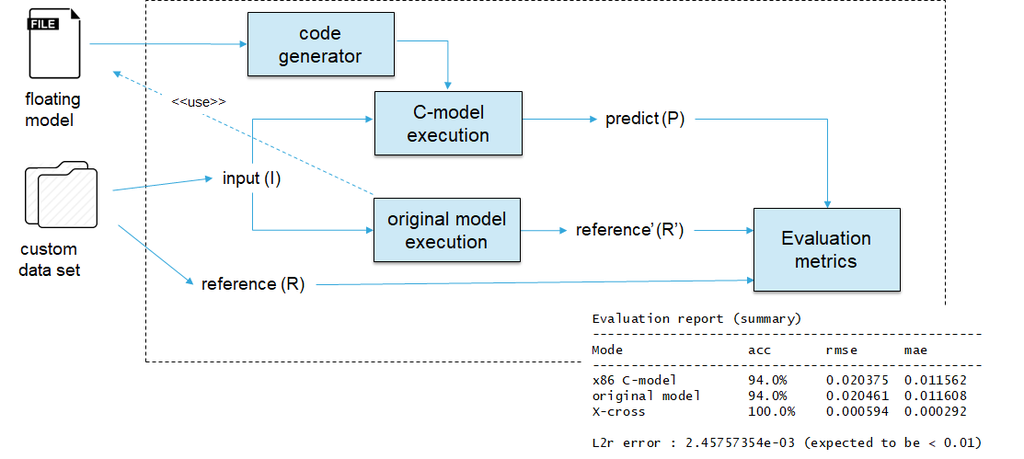

Figure 7: Floating-point model with IO values

Typical output during the execution of the `validate` command with custom data and compression factor.

```bash
$ $ stm32ai validate -m <model_file_path> -vi test_data.npz -c 8

...
-- Setting inputs (and outputs) data
Using user-provided input file, shape=(50, 64, 64, 1)
Using reference output file, shape=(50, 8)
-- Setting inputs (and outputs) data - done (elapsed time 0.064s)
...
Accuracy report for the generated x86 C-model
----------------------------------------------------------------------------------------------------
NOTE: Computed against the provided ground truth values

acc=94.00%, rmse=0.0224, mae=0.0127

8 classes (50 samples)
------------------------------------------------
C0         4    .    .    .    .    .    .    .
C1         .    8    .    .    .    .    .    .
C2         .    .    6    .    .    .    1    .
C3         .    .    .    7    .    .    .    .
C4         .    .    .    .    5    .    .    .
C5         .    1    .    .    .    6    1    .
C6         .    .    .    .    .    .    5    .
C7         .    .    .    .    .    .    .    6

Accuracy report for the reference model
----------------------------------------------------------------------------------------------------
NOTE: Computed against the provided ground truth values

acc=94.00%, rmse=0.0205, mae=0.0116

8 classes (50 samples)
------------------------------------------------
C0         4    .    .    .    .    .    .    .
C1         .    8    .    .    .    .    .    .
C2         .    .    6    .    .    .    1    .
C3         .    .    .    7    .    .    .    .
C4         .    .    .    .    5    .    .    .
C5         .    1    .    .    .    6    1    .
C6         .    .    .    .    .    .    5    .
C7         .    .    .    .    .    .    .    6

Cross accuracy report (reference vs C-model)
----------------------------------------------------------------------------------------------------
NOTE: the output of the reference model is used as ground truth value

acc=100.00%, rmse=0.0063, mae=0.0034

8 classes (50 samples)
------------------------------------------------
C0         4    .    .    .    .    .    .    .
C1         .    9    .    .    .    .    .    .
C2         .    .    6    .    .    .    .    .
C3         .    .    .    7    .    .    .    .
C4         .    .    .    .    5    .    .    .
C5         .    .    .    .    .    6    .    .
C6         .    .    .    .    .    .    7    .
C7         .    .    .    .    .    .    .    6


Creating <output-directory-path>\<name>_valid_m_inputs.csv
Creating <output-directory-path>\<name>_valid_c_inputs.csv
Creating <output-directory-path>\<name>_valid_m_outputs.csv
Creating <output-directory-path>\<name>_valid_c_outputs.csv
Creating <output-directory-path>\<name>_valid_io.npz

Evaluation report (summary)
--------------------------------------------------
Mode                acc       rmse      mae
--------------------------------------------------
x86 C-model         94.0%     0.022430  0.012718
original model      94.0%     0.020461  0.011608
X-cross             100.0%    0.006338  0.003373

L2r error : 2.63014436e-02 (expected to be < 0.01)
...
```

## 3.4 Quantized model - Input/output values

This case is the preferable validation flow (fig. 8) to evaluate the generated C-model for a quantized model. The provided outputs (ground truth values) are used to evaluate the classification accuracy of the *reshaped floating-point* model and the C-model of the quantized version.

[figure not shown]

Figure 8: Quantized model with IO values

**Note** — Saved `'c_inputs'` values are the converted version of the `'m_inputs'`/*‘I’*. `'c_outputs'`/*‘P’* are the floating version of the C-outputs.

Typical output during the execution of the `validate` command.

```bash
$ stm32ai validate -m <modified_model_file>.h5 -q <quant_file_desc>.json -vi test_data.npz
...
-- Setting inputs (and outputs) data
Using user-provided input file, shape=(50, 64, 64, 1)
Inputs are quantized, format=(8, -1)
Using reference output file, shape=(50, 8)
-- Setting inputs (and outputs) data - done (elapsed time 0.064s)
...
Accuracy report for the generated x86 C-model
----------------------------------------------------------------------------------------------------
NOTE: Computed against the provided ground truth values

acc=94.00%, rmse=0.1493, mae=0.0824

8 classes (50 samples)
------------------------------------------------
C0         4    .    .    .    .    .    .    .
C1         .    8    .    .    .    .    .    .
C2         1    .    5    .    .    .    1    .
C3         .    .    .    7    .    .    .    .
C4         .    .    .    .    5    .    .    .
C5         .    .    .    .    .    8    .    .
C6         .    .    1    .    .    .    4    .
C7         .    .    .    .    .    .    .    6

Accuracy report for the reference model
----------------------------------------------------------------------------------------------------
NOTE: Computed against the provided ground truth values

acc=94.00%, rmse=0.0205, mae=0.0116

8 classes (50 samples)
------------------------------------------------
C0         4    .    .    .    .    .    .    .
C1         .    8    .    .    .    .    .    .
C2         .    .    6    .    .    .    1    .
C3         .    .    .    7    .    .    .    .
C4         .    .    .    .    5    .    .    .
C5         .    1    .    .    .    6    1    .
C6         .    .    .    .    .    .    5    .
C7         .    .    .    .    .    .    .    6

Cross accuracy report (reference vs C-model)
----------------------------------------------------------------------------------------------------
NOTE: the output of the reference model is used as ground truth value

acc=92.00%, rmse=0.1566, mae=0.0873

8 classes (50 samples)
------------------------------------------------
C0         4    .    .    .    .    .    .    .
C1         .    8    .    .    .    1    .    .
C2         1    .    5    .    .    .    .    .
C3         .    .    .    7    .    .    .    .
C4         .    .    .    .    5    .    .    .
C5         .    .    .    .    .    6    .    .
C6         .    .    1    .    .    1    5    .
C7         .    .    .    .    .    .    .    6

Creating <output-directory-path>\<name>_valid_m_inputs.csv
Creating <output-directory-path>\<name>_valid_c_inputs.csv
Creating <output-directory-path>\<name>_valid_m_outputs.csv
Creating <output-directory-path>\<name>_valid_c_outputs.csv
Creating <output-directory-path>\<name>_valid_io.npz

Evaluation report (summary)
--------------------------------------------------
Mode                acc       rmse      mae
--------------------------------------------------
x86 C-model         94.0%     0.149257  0.082441
original model      94.0%     0.020461  0.011608
X-cross             92.0%     0.156579  0.087279

L2r error : NOT EVALUATED
...
```

# 4 Post-processing example

Following log is the output of a typical custom Python script to read the generated samples and to build new element-wise metrics: `'variance'` and `'f1_score'` (thanks to the *numpy* and *sklearn.metrics* Python modules). `'acc'`, `'rmse'`, `'mae'` and `'l2r'` are also provided to illustrate how these metrics are computed.

```bash
$ python custom_metrics.py
Read generated NPZ file "./stm32ai_output\network_val_io.npz"...
Read generated CSV files "./stm32ai_output\network_val_*.csv"...
Read reference NPZ file "network_reference.npz"...

Evaluation report
--------------------------------------------------------------------------------
               acc       rmse      mae       var       f1_score  l2r
--------------------------------------------------------------------------------
C-model        94.0%     0.149257  0.082441  0.022333  0.932265  0.44756502
original model 94.0%     0.020461  0.011608  0.000420  0.944341  0.08464438
X-cross        92.0%     0.156579  0.087279  0.024577  0.919234  0.46952036
```

Full code of the custom Python script.

```python
# -*- coding: utf-8 -*-
"""
Implement custom metrics
"""
from __future__ import absolute_import
from __future__ import division
from __future__ import print_function

import os
import numpy as np
import argparse

from sklearn.metrics import mean_squared_error
from sklearn.metrics import accuracy_score
from sklearn.metrics import f1_score

OUTPUT_DIR = './stm32ai_output'
NETWORK_NAME = 'network'
REFERENCE_NPZ = 'network_reference.npz'

# metrics

def mse(ref, pred):
  """Return Mean Squared Error (MSE)."""
  return ((ref - pred).astype(np.float64) ** 2).mean()

def rmse(ref, pred):
  """Return Root Mean Squared Error (RMSE)."""
  return np.sqrt(((ref - pred).astype(np.float64) ** 2).mean())

def mae(ref, pred):
  """Return Mean Absolute Error (MAE)."""
  return (np.abs(ref - pred).astype(np.float64)).mean()

def var(ref, pred):
  """Return Variance"""
  return np.var((ref - pred), dtype=np.float64, ddof=1)

def acc(ref, pred):
  """Classification accuracy (ACC)."""
  return accuracy_score(np.argmax(ref, axis=1), np.argmax(pred, axis=1))

def f1_s(ref, pred, average='macro'):
  """Compute the F1 score, also known as balanced F-score or F-measure (F1)"""
  return f1_score(np.argmax(ref, axis=1), np.argmax(pred, axis=1), average=average)

def l2r(ref, pred):
  """Compute L2 relative error"""
  def magnitude(v):
    return np.sqrt(np.sum(np.square(v).flatten()))
  mag = magnitude(pred) + np.finfo(np.float32).eps
  return magnitude(ref - pred) / mag

# read the generated inputs and predicted samples (origninal & C models)

fname = os.path.join(OUTPUT_DIR, NETWORK_NAME + '_val_io.npz')
print('Read generated NPZ file "{}"...'.format(fname))
arrays = np.load(fname)

i_  = arrays['m_inputs']
ic_  = arrays['c_inputs']
p_  = arrays['c_outputs']
pm_ = arrays['m_outputs']

fname = os.path.join(OUTPUT_DIR, NETWORK_NAME + '_val_*.csv')
print('Read generated CSV files "{}"...'.format(fname))

fname = os.path.join(OUTPUT_DIR, NETWORK_NAME + '_val_m_inputs.csv')
i_csv_ = np.atleast_2d(np.genfromtxt(fname, delimiter=','))
fname = os.path.join(OUTPUT_DIR, NETWORK_NAME + '_val_c_inputs.csv')
ic_csv_ = np.atleast_2d(np.genfromtxt(fname, delimiter=','))
fname = os.path.join(OUTPUT_DIR, NETWORK_NAME + '_val_c_outputs.csv')
p_csv_ = np.atleast_2d(np.genfromtxt(fname, delimiter=','))
fname = os.path.join(OUTPUT_DIR, NETWORK_NAME + '_val_m_outputs.csv')
pm_csv_ = np.atleast_2d(np.genfromtxt(fname, delimiter=','))

l_csv = len(i_csv_)

# read reference samples

print('Read reference NPZ file "{}"...'.format(REFERENCE_NPZ))

fname = REFERENCE_NPZ
arrays = np.load(fname)

i_ref = arrays['in_0']
r_ref = arrays['out_0']

# reshape the _csv data

i_csv_ = i_csv_.reshape((-1,) + i_.shape[1:])
p_csv_ = p_csv_.reshape((-1,) + p_.shape[1:])
pm_csv_ = pm_csv_.reshape((-1,) + pm_.shape[1:])

# calculate metrics

def build_metrics(ref, pred):
  res = {}
  res['acc'] = acc(ref, pred)
  res['var'] = var(ref, pred)
  res['f1_score'] = f1_s(ref, pred)
  res['rmse'] = rmse(ref, pred)
  res['mae'] = mae(ref, pred)
  res['mse'] = mse(ref, pred)
  res['l2r'] = l2r(ref, pred)
  return res

def print_metrics(name, ref, pred):
  res = build_metrics(ref, pred)
  str = '{:15s}'.format(name)
  _acc = '{:.1f}%'.format(res['acc'] * 100.0)
  str += '{:10s}'.format(_acc)
  str += '{:.6f}  '.format(res['rmse'])
  str += '{:.6f}  '.format(res['mae'])
  str += '{:.6f}  '.format(res['var'])
  str += '{:.6f}  '.format(res['f1_score'])
  str += '{:.8f}  '.format(res['l2r'])
  print(str)

print('\nEvaluation report')
print('-'*80)
print('               {:8s}  {:8s}  {:8s}  {:8s}  {:8s}  {:8s}'.format('acc', 'rmse',
          'mae', 'var', 'f1_score', 'l2r'))
print('-'*80)
print_metrics('C-model', r_ref, p_)
print_metrics('original model', r_ref, pm_)
print_metrics('X-cross', pm_, p_)
```

# 5 Revision history

| Date | version | changes |
| --- | --- | --- |
| **2019-07-2** | r1.0 | initial version |

Online Documentation - Evaluation report and metrics  
**X-CUBE-AI 4.0.0 Expansion Package**  
r1.0 - AI PLATFORM r4.0.0 (Embedded Inference Client API 1.3.0) - Command Line Interface r1.0.0

Information in this document is provided solely in connection with ST products. The contents of this document are subject to change without prior notice.  
© Copyright STMicroelectronics 2019. All rights reserved. www.st.com